[figure not shown]

**Universidade Estadual de Campinas – Instituto de Matemática, Estatística e**

**Computação Científica (IMECC)**

**Disciplina: ME 115 – Linguagem R**  
**Nomes**: Thiago Henrique Paes 256302, Alejandro Francisco Figueiredo 230532, Eddie Aikau Abatepaulo 204248 e João Francisco Figueiredo Miranda 218592.

**Conjunto de Dados “Marijuana Arrests in Columbia”**

### **Introdução**

No Distrito de Colúmbia (Washington, D.C., EUA), a polícia da narcóticos, a fim de identificar alguns percentuais e taxas de crimes de apreensão de maconha entre os anos de 2012 e 2022, além de controlar e erradicar, precisa, analítica e estatisticamente, relacionar algumas variáveis e observações em um grande conjunto de dados. Tal conjunto é composto por 13.063 observações (linhas) e 27 variáveis (colunas). Dessa forma, algumas perguntas de interesse foram realizadas com o propósito de solucionar alguns problemas e preencher lacunas existentes.

#### Perguntas de interesse:

#### Análise das colunas TYPE e OFFENSE_DISTRICT

1. Qual é o principal tipo de delito relacionado com o maior número de apreensões?
2. Qual o bairro/distrito que ocorre as principais apreensões desse tipo de delito?
3. Gráfico dos crimes de posse e posse com intenção de distribuição (tráfico de maconha) por bairro/distrito dentro do estado de Colúmbia.

#### Análise das colunas OFFENSE_DISTRICT e DEFENDANT_DISTRICT

1. Qual o bairro/distrito que ocorre mais apreensões?
2. Qual o bairro/distrito com o maior número de detentos?

#### Análise das colunas TYPE e ADULT_JUVENILE

1. Quantas apreensões foram registradas como consumo próprio?
2. Qual a porcentagem de menores detidos por consumo próprio?
3. Qual a porcentagem de menores envolvidos em cada tipo de delito?

#### Análise das colunas DATETIME e YEAR

1. Quais são os períodos com maior frequência de tráfico?
2. Qual o horário com maior ocorrência?
3. Qual ano mostrou maior atividade?
4. Analisando os anos, pode apontar uma diferença entre eles?

#### Análise das colunas AGE e TYPE

1. Qual a idade média de pessoas envolvidas com algum delito relacionado à maconha?

## Descrição do Conjunto de Dados

O nome, tipo e a descrição de variável são as seguintes:

| Nome da Variável | Descrição resumida da variável | Tipo da Variável |
| --- | --- | --- |
| TYPE (Tipo) | Indica o tipo de prisão | Texto |
| ADULT_JUVENILE | Especifica se o adulto detido é adulto ou jovem | Texto |
| YEAR (Ano) | O ano em que ocorreu a prisão | Numérico |
| DATETIME (Data-Tempo) | A data e hora da prisão | Numérico |
| AGE (Idade) | A idade do detido no momento da detenção | Numérico |
| OFFENSE_DISTRICT | “Bairro” da Ofensa | Texto |
| OFFENSE_PSA | Área de Serviço Policial associada ao acusado | Numérico |
| DEFENDANT_DISTRICT | “Bairro” do Detento | Texto |
| RACE | A raça do réu, com base na observação oficial | Texto |
| ETHNICITY | A etnia do réu, com base na observação oficial | Texto |
| CATEGORY | Departamento responsável | Texto |
| DESCRIPTION | Descrição do crime | Texto |
| ADDRESS | O endereço do local do crime | Texto |
| CREATOR | O criador do registro | Texto |
| EDITOR | O editor do disco | Texto |
| EDITED | A data e hora em que o registro foi editado | Texto |
| OBJECTID | Identificador único para cada registro | Numérico |
| GLOBALID | Identificador exclusivo global para cada registro | Numérico |
| SEX | Sexo do réu | Texto |
| CCN | Número de hash que permite aos indivíduos determinar se há várias prisões associadas a um evento | Texto |
| OFFENSE_BLOCKX | Coordenada X da localização aproximada do bloco da ofensa | Numérico |
| OFFENSE_BLOCKY | Coordenada Y da localização aproximada do bloco da ofensa | Numérico |
| ARREST_BLOCKX | Coordenada X da localização aproximada do bloco da prisão | Numérico |
| ARREST_BLOCKY | Coordenada Y da localização aproximada do bloco da prisão | Numérico |
| GIS_ID | ID do Sistema de Informações Geográficas (GIS) associado ao registro | Texto |
| CREATED | A data e hora em que o registro foi criado | Texto |

**Fonte:** Disponível em: https://www.usa.gov/government-works/. Acesso em: 24 de junho de 2023.

## Análise Exploratória e Descritiva

Primeiro carregamos todas as bibliotecas necessarias que serão utilizadas no código

### Gráficos das Análises

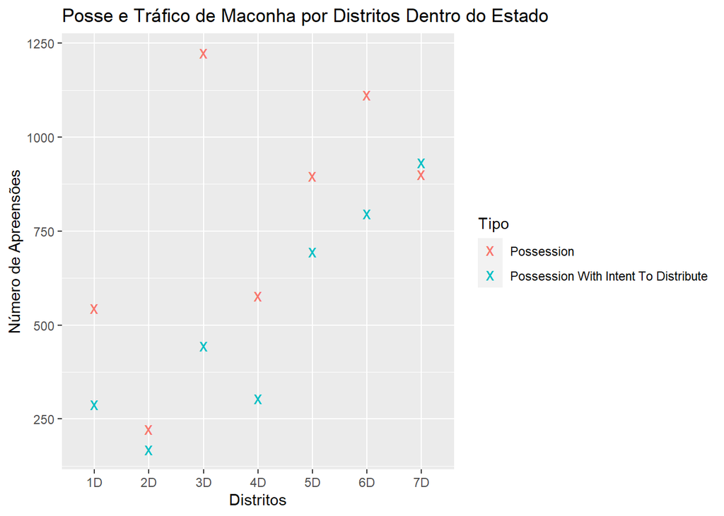

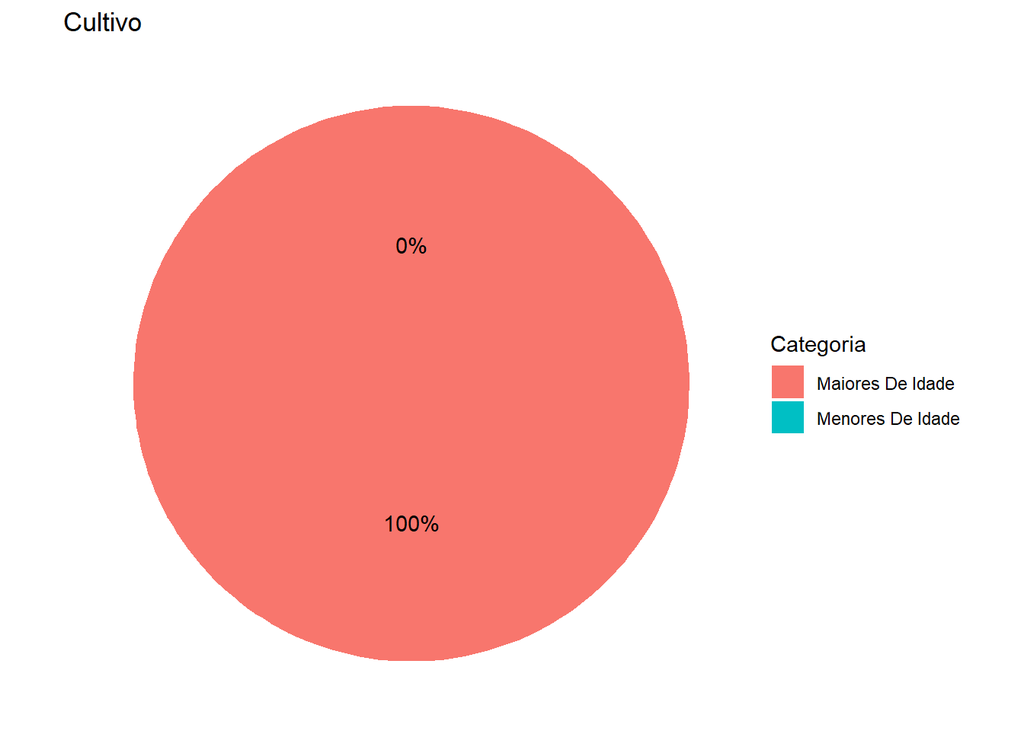

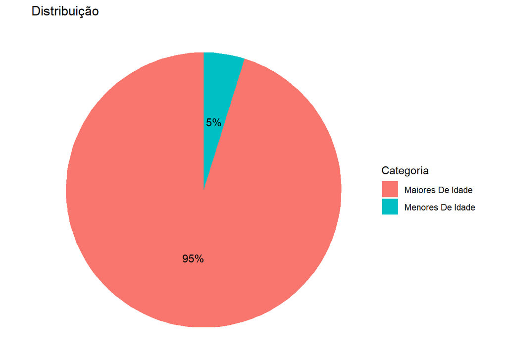

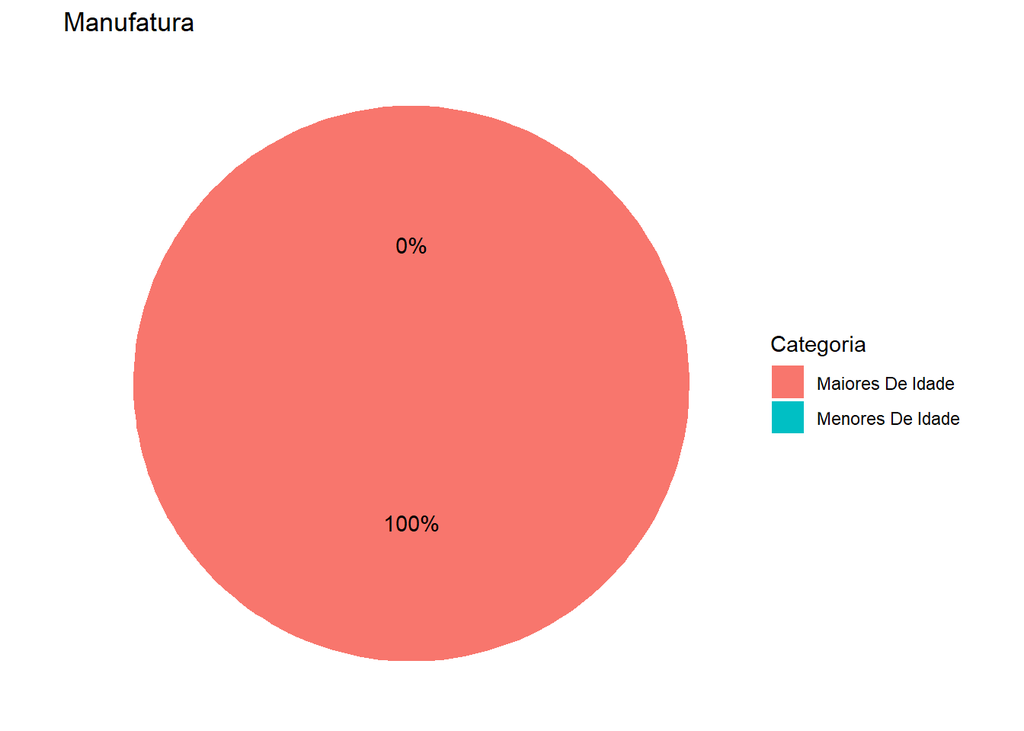

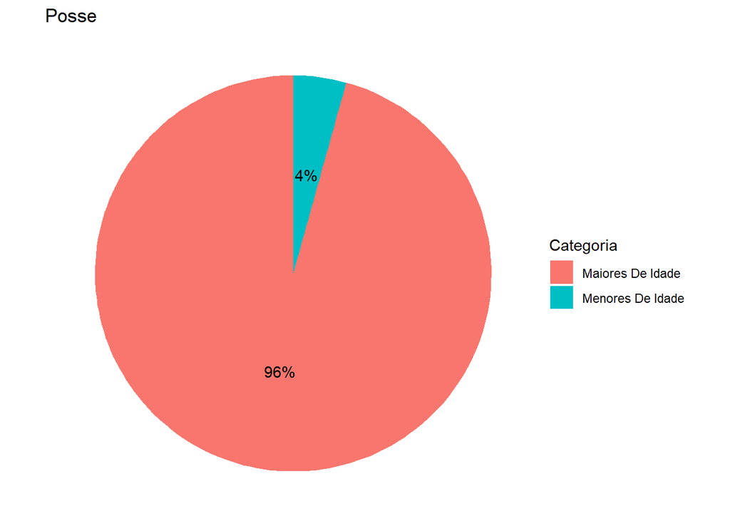

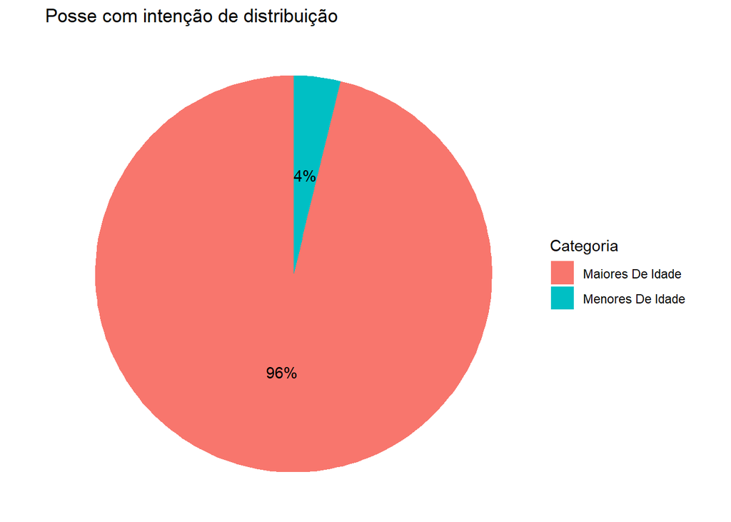

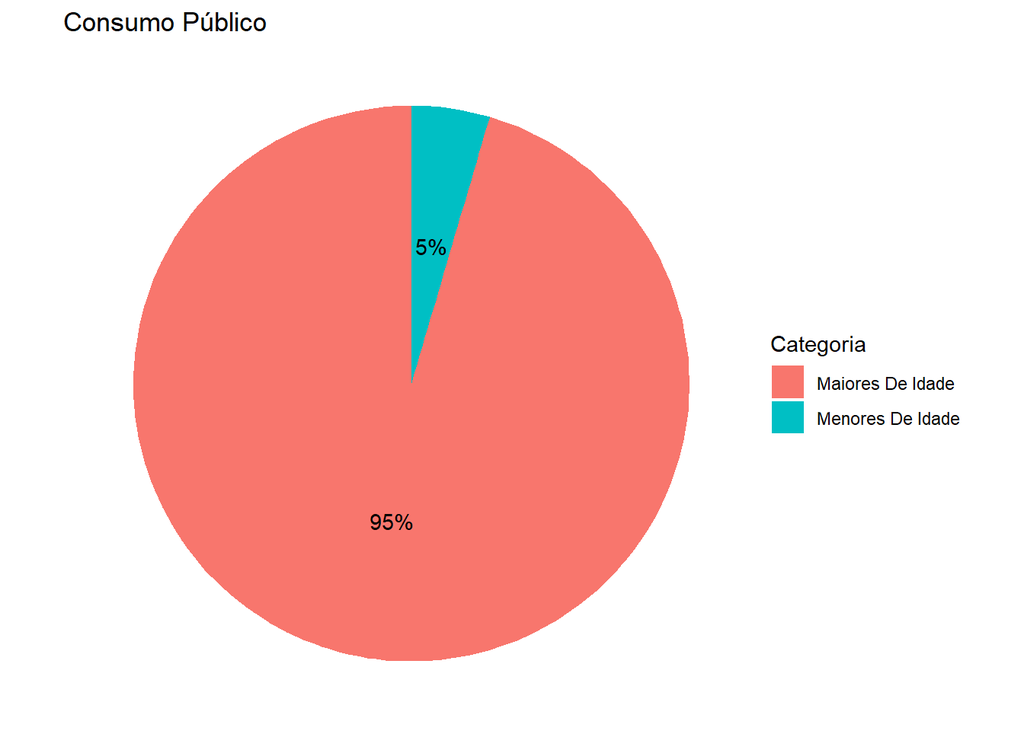

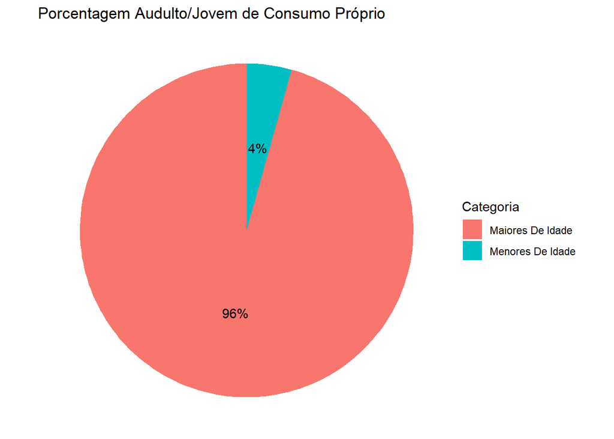

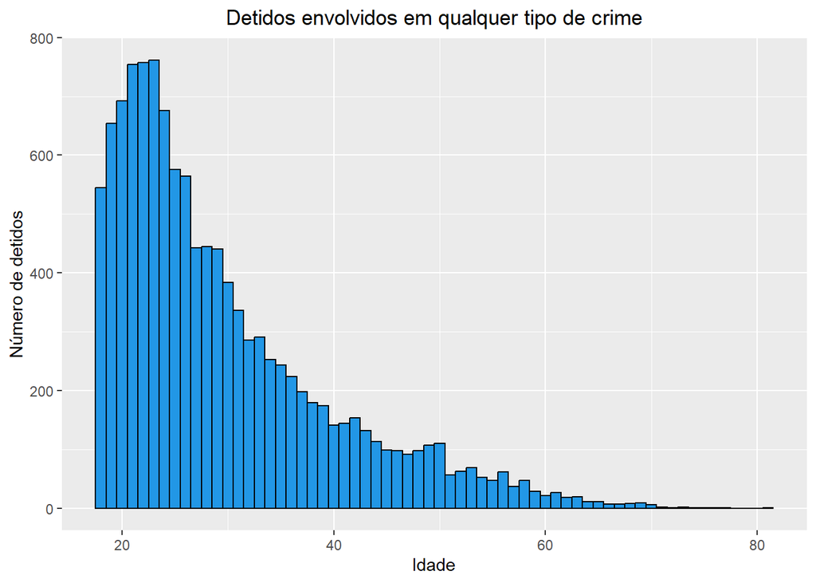

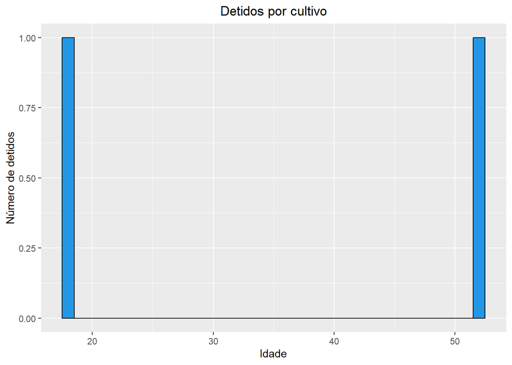

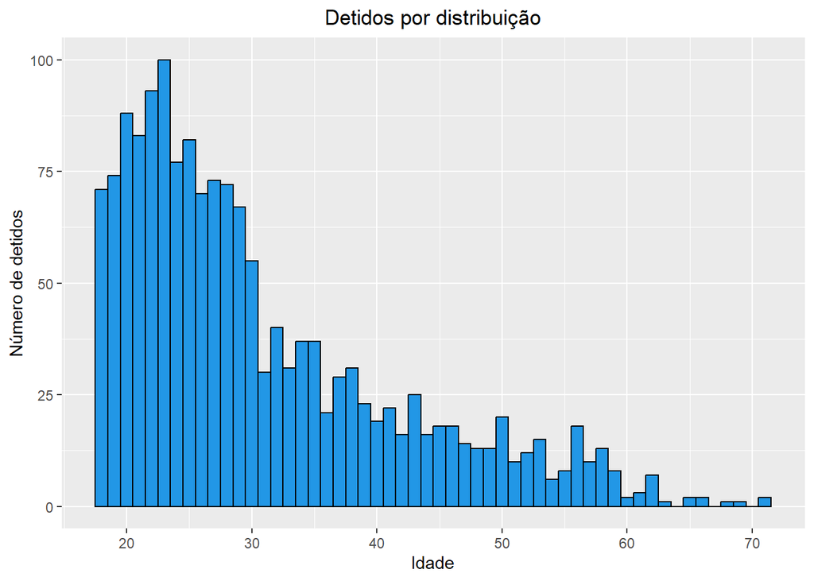

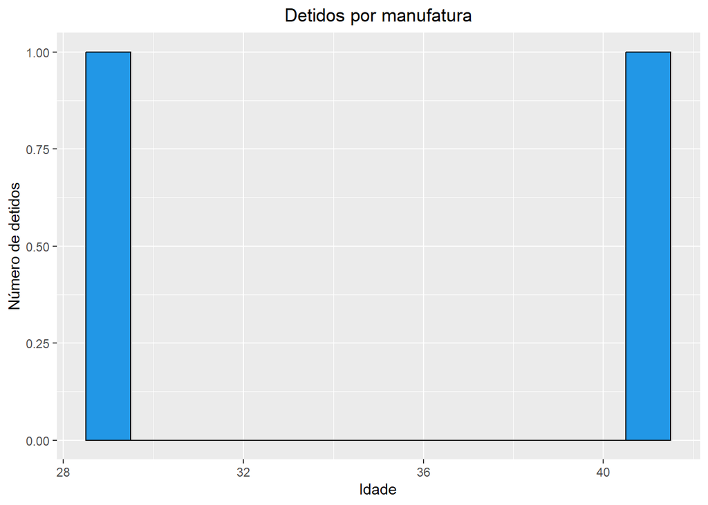

[7 more figures not shown]

### **Conclusão**

Com base nas análises realizadas, foi possível aferir algumas pontuações. Primeiramente, em relação às observações um e dois, o Distrito de Colúmbia apresenta bairros com maiores índices de apreensões. O Distrito 7, localizado na fronteira com o estado de Maryland, possui as maiores taxas de criminalidade por tráfico de maconha e na quantidade no número de detentos. Por isso, o Governo de Washington D.C. deve concentrar sua atenção nessa região, aumentando a força policial, inclusive com parceria com o estado de Maryland, tendo em vista que grande parte das drogas podem vir de fora, ou seja, de outro estado. Além disso, para evitar possíveis sobrecargas no número de detentos desse distrito, deve-se construir mais infraestruturas de contenção.

Por outro lado, o número de apreensões por posse de maconha foi maior no distrito 3, localizado na extremidade oposta ao distrito número 7. Supostamente, a droga pode ter passado pelos outros distritos até chegar nele (por meio de alguma brecha), ou ainda, ter vindo de outro estados. Desse modo, no distrito 3, seria interessante a criação de campanhas de conscientização, evitando problemas de saúde relacionados à droga em questão.

Pode-se observar que o tráfico de drogas ocorre durante a noite e madrugada, levantando a hipótese de que esse horário é mais discreto em relação ao dia e conta com uma presença policial menor em comparação à manhã. Além disso, esse período também coincide com festas, sendo um momento em que as pessoas têm maior propensão a fazer uso de drogas.

Analisando os anos de 2012 até 2021, foi observado que em 2012 houve a liberação do uso de 28 gramas de maconha para adultos acima de 21 anos. Essa medida resultou em uma pequena queda no tráfico de maconha. Em 2015, ocorreu a legalização de 60 gramas de maconha por adulto, além da permissão para o cultivo de 6 plantas de maconha em casa. Essas ações contribuíram para uma queda significativa no número de casos de tráfico. No entanto, houve um aumento gradual até 2018, quando foram identificadas algumas irregularidades na legislação, como o uso de “presentes” para burlar as regras. Diante disso, novos regulamentos foram estabelecidos, resultando em uma nova redução no tráfico, atingindo patamares ainda mais baixos em comparação a 2012.

### **Bibliografia**

##### Banco de Dados

https://www.kaggle.com/datasets/utkarshx27/marijuana-arrests-in-columbia

##### Documentação do R

https://www.r-project.org/other-docs.html